# Tarea 5

m1ch3ll3

3/12/2018

## Entregables

### Foto de mi cluster

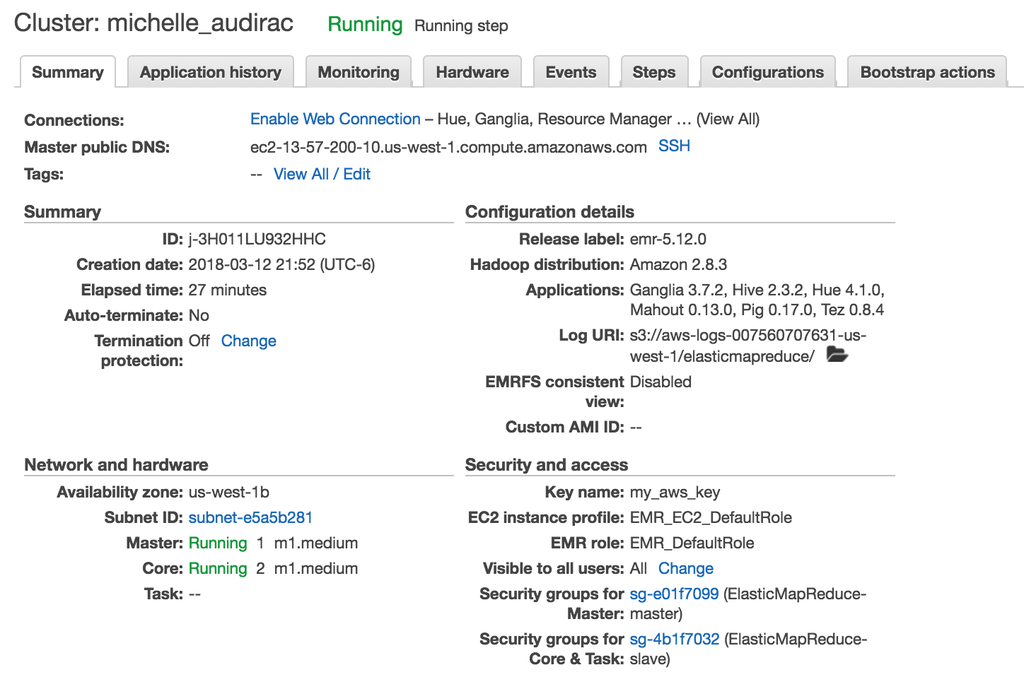

### Ejercicio 1a

1a. ¿Cuántos “jefes” hay en la tabla empleados? ¿Cuáles son estos jefes: número de empleado, nombre, apellido, título, fecha de nacimiento, fecha en que iniciaron en la empresa, ciudad y país? (atributo reportsto, ocupa explode en tu respuesta)

- hive query

```bash
cat ./1a/1a.hql
```

```
## USE northwind;
##
## SELECT DISTINCT r.headid, e.firstname, e.lastname, e.title, e.birthdate, e.hiredate, e.city, e.country
## FROM (SELECT explode(collect_set(reportsto)) as headid FROM employees) r JOIN employees e
## ON (r.headid = e.employeeid);
```

El output se encuentra en ./1a/output y se ve así

```bash
cat ./1a/output/1a
```

```
## /usr/bin/hive
## 2    Andrew  Fuller  "Vice President Dr. 1952-02-19  908 W. Capital Way  98401
## 5    Steven  Buchanan    Sales Manager   1955-03-04  1993-10-17  London  UK
```

### Ejercicio 1b

1b. ¿Quién es el segundo “mejor” empleado que más órdenes ha generado? (nombre, apellido, título, cuándo entró a la compañía, número de órdenes generadas, número de órdenes generadas por el mejor empleado (número 1))

- hive query

```bash
cat ./1b/1b.hql
```

```
## USE northwind;
##
## SELECT DISTINCT e.firstname, e.lastname, e.title, e.hiredate, q.ce1, q.cn1, q.cn0
## FROM (SELECT c.e[1] as ce1, c.n[1] as cn1, c.n[0] as cn0
## FROM (SELECT collect_set(o.employeeid) as e, collect_set(o.n) as n
## FROM (SELECT employeeid, COUNT(employeeid) n
## FROM orders
## GROUP BY employeeid
## ORDER BY n DESC) o) c) q JOIN employees e
## ON (q.ce1==e.employeeid);
```

El output se encuentra en ./1b/output y se ve así

```bash
cat ./1b/output/1b
```

```
## /usr/bin/hive
## Janet    Leverling   Sales Representative    1992-04-01  3   127 156
```

### Ejercicio 1c

1c. ¿Cuál es el delta de tiempo más grande entre una orden y otra?

- hive query

```bash
cat ./1c/1c.hql
```

```
## USE northwind;
##
## SELECT orderid, orderdate, lag(orderdate) OVER(ORDER BY orderid),
## datediff(orderdate, lag(orderdate) OVER(ORDER BY orderid)) delta
## FROM orders
## ORDER BY delta DESC
## LIMIT 5;
```

- La delta más grande es 3

El output se encuentra en ./1b/output y se ve así

```bash
cat ./1c/output/1c
```

```
## /usr/bin/hive
## 10250    1996-07-08  1996-07-05  3
## 11067    1998-05-04  1998-05-01  3
## 10273    1996-08-05  1996-08-02  3
## 10256    1996-07-15  1996-07-12  3
## 10262    1996-07-22  1996-07-19  3
```

### Ejercicio 2a

2a. ¿Qué aerolíneas (nombres) llegan al aeropuerto “Honolulu International Airport”?

- hive query

```bash
cat ./2a/2a.hql
```

```
## USE flights;
##
## SELECT a.airline
## FROM (SELECT DISTINCT airline
## FROM flights
## WHERE destination_airport = 'HNL') h RIGHT JOIN airlines a
## ON (h.airline = a.iata_code);
```

El output se encuentra en ./2a/output y se ve así

```bash
cat ./2a/output/2a
```

```
## /usr/bin/hive
## American Airlines Inc.
## Alaska Airlines Inc.
## JetBlue Airways
## Delta Air Lines Inc.
## Atlantic Southeast Airlines
## Frontier Airlines Inc.
## Hawaiian Airlines Inc.
## American Eagle Airlines Inc.
## Spirit Air Lines
## Skywest Airlines Inc.
## United Air Lines Inc.
## US Airways Inc.
## Virgin America
## Southwest Airlines Co.
```

### Ejercicio 2b

2b. ¿En qué horario (hora del día, no importan los minutos) hay salidas del aeropuerto de San Francisco (“SFO”) a “Honolulu International Airport”

- hive query

```bash
cat ./2b/2b.hql
```

```
## USE flights;
##
## SELECT DISTINCT floor(scheduled_departure / 100)
## FROM flights
## WHERE destination_airport = 'HNL'
## AND origin_airport = 'SFO';
```

El output se encuentra en ./2b/output y se ve así

```bash
cat ./2b/output/2b
```

```
## 8
## 10
## 11
## 17
## 18
## 19
## 9
## 13
## 14
## 16
## 6
## 7
## 12
## 15
```

### Ejercicio 2c

2c. ¿Qué día de la semana y en qué aerolínea nos conviene viajar a “Honolulu International Airport” para tener el menor retraso posible?

- hive query

```bash
cat ./2c/2c.hql
```

```
## USE flights;
##
## SELECT avg(arrival_delay) d, day_of_week, airline
## FROM flights
## WHERE destination_airport = 'HNL'
## GROUP BY day_of_week, airline
## ORDER BY d
## LIMIT 3;
```

El output se encuentra en ./2c/output y se ve así

```bash
cat ./2c/output/2c
```

```
## /usr/bin/hive
## -14.222222222222221  1   VX
## -11.125  6   VX
## -10.25   5   VX
```

### Ejercicio 2d

2d. ¿Cuál es el aeropuerto con mayor tráfico de entrada?

- hive query

```bash
cat ./2d/2d.hql
```

```
## USE flights;
##
## SELECT destination_airport , count(destination_airport) n
## FROM flights
## GROUP BY destination_airport
## ORDER BY n DESC
## LIMIT 3;
```

- tenemos registrados 693,808 vuelos con destino a ATL (Hartsfield-Jackson Atlanta International Airport)

El output se encuentra en ./2d/output y se ve así

```bash
cat ./2d/output/2d
```

```
## /usr/bin/hive
## ATL  693808
## ORD  571812
## DFW  479164
```

### Ejercicio 2e

2e. ¿Cuál es la aerolínea con mayor retraso de salida por día de la semana?

- hive query

```bash
cat ./2e/2e.hql
```

```
## USE flights;
##
## SELECT rank() OVER(PARTITION BY f.day_of_week ORDER BY f.d DESC) rank, f.day_of_week, f.airline, f.d
## FROM (SELECT day_of_week, airline, avg(departure_delay) d
## FROM flights
## GROUP BY day_of_week, airline) f
## ORDER BY rank
## LIMIT 7;
```

- tenemos que los días de la semana 3 y 4 (martes y miércoles) es UA (United Airlines) y el resto de los días es NK (Spirit Air Lines)

El output se encuentra en ./2e/output y se ve así

```bash
cat ./2e/output/2e
```

```
## /usr/bin/hive
## 1    1   NK  18.795626679697044
## 1    7   NK  17.149202320522118
## 1    4   UA  14.88742760925581
## 1    3   UA  14.282200834726739
## 1    6   NK  15.780295269659536
## 1    2   NK  15.714659197012137
## 1    5   NK  15.786104837751099
```

### Ejercicio 2f

2f. ¿Cuál es la tercer aerolínea con menor retraso de salida los lunes (day of week = 2)?

- hive query

```bash
cat ./2f/2f.hql
```

```
## USE flights;
##
## SELECT rank() OVER (ORDER BY avg(departure_delay) DESC), airline
## FROM flights
## WHERE day_of_week = 2
## GROUP BY airline
## LIMIT 5;
```

El output se encuentra en ./2f/output y se ve así

```bash
cat ./2f/output/2f
```

```
## /usr/bin/hive
## 1    NK
## 2    UA
## 3    F9
## 4    B6
## 5    WN
```

### Ejercicio 2g

2g. ¿Cuál es el aeropuerto origen que llega a la mayor cantidad de aeropuertos destino diferentes?

- hive query

```bash
cat ./2g/2g.hql
```

```
## USE flights;
##
## SELECT origin_airport, count(DISTINCT destination_airport) n
## FROM flights
## GROUP BY origin_airport
## ORDER BY n DESC
## LIMIT 3;
```

- tenemos que el aeropuerto con mayor cantidad de destinos es ATL (Hartsfield-Jackson Atlanta International Airport) con 169 destinos

El output se encuentra en ./2g/output y se ve así

```bash
cat ./2g/output/2g
```

```
## /usr/bin/hive
## ATL  169
## ORD  162
## DFW  148
```